## Zentraler Grenzwertsatz

**Wenn man viele unabhängige Zufallszahlen aufaddiert, ist die Verteilung der Summe glocken-förmig. Die Form ist immer dieselbe, egal, was man aufaddiert (wenn es nur genügend Zahlen sind, und sie unabhängig sind). Man kann die Form durch zwei Größen beschreiben: den Mittelwert und die Standardabweichung (Breite). Der Rest ist djurch die Formel der Normalverteilung gegeben.**

## Demonstration des zentralen Grenzwertsatzes

Ein Würfel

```r
sample( 6, 1 )
```

```
## [1] 2
```

Jeder Wert ist gleich wahrscheinlich

```r
table( sample( 6, 10000, replace=TRUE ) )
```

```
##
##    1    2    3    4    5    6
## 1657 1620 1708 1637 1681 1697
```

Zwei Würfel, aufaddiert

```r
sum( sample( 6, 2 ) )
```

```
## [1] 7
```

Werte in der Mitte werden wahrscheinlicher

```r
table( rowSums( matrix( sample( 6, 20000, replace=TRUE ), ncol=2 ) ) )
```

```
##
##    2    3    4    5    6    7    8    9   10   11   12
##  267  584  833 1119 1393 1632 1372 1082  865  563  290
```

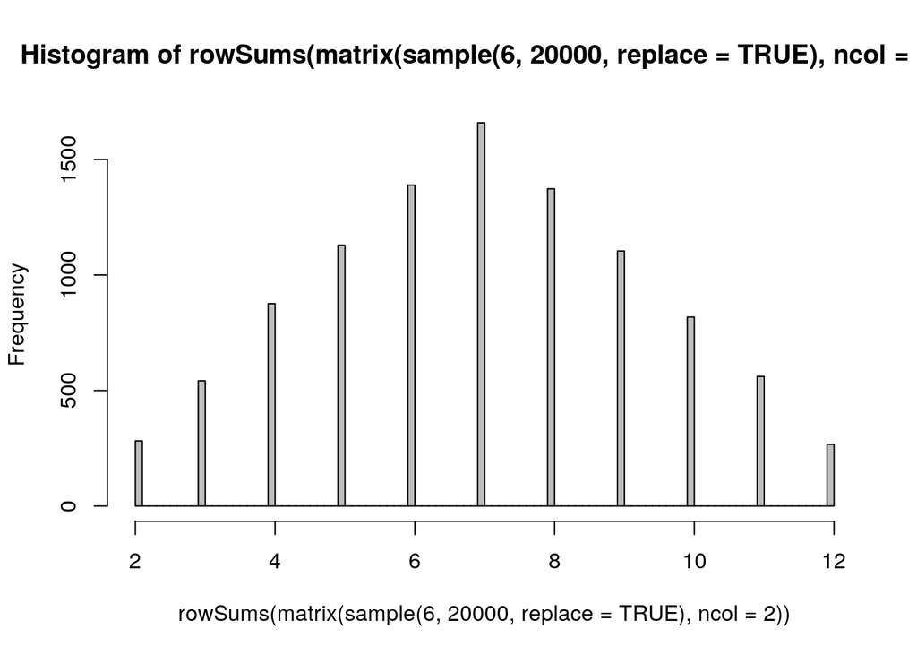

```r
hist( rowSums( matrix( sample( 6, 20000, replace=TRUE ), ncol=2 ) ), col="gray", breaks=100)
```

Drei Würfel aufaddiert: Die Spitze wird abgerundet:

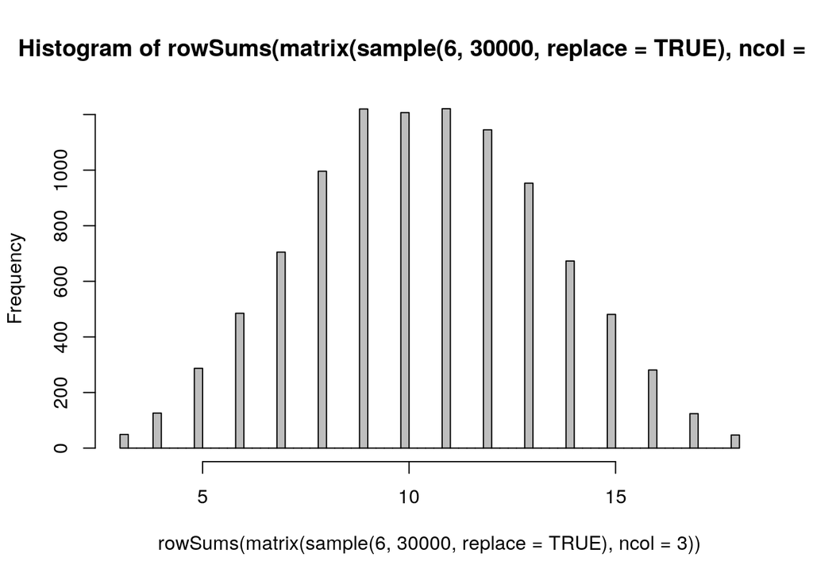

```r
hist( rowSums( matrix( sample( 6, 30000, replace=TRUE ), ncol=3 ) ), col="gray", breaks=100)
```

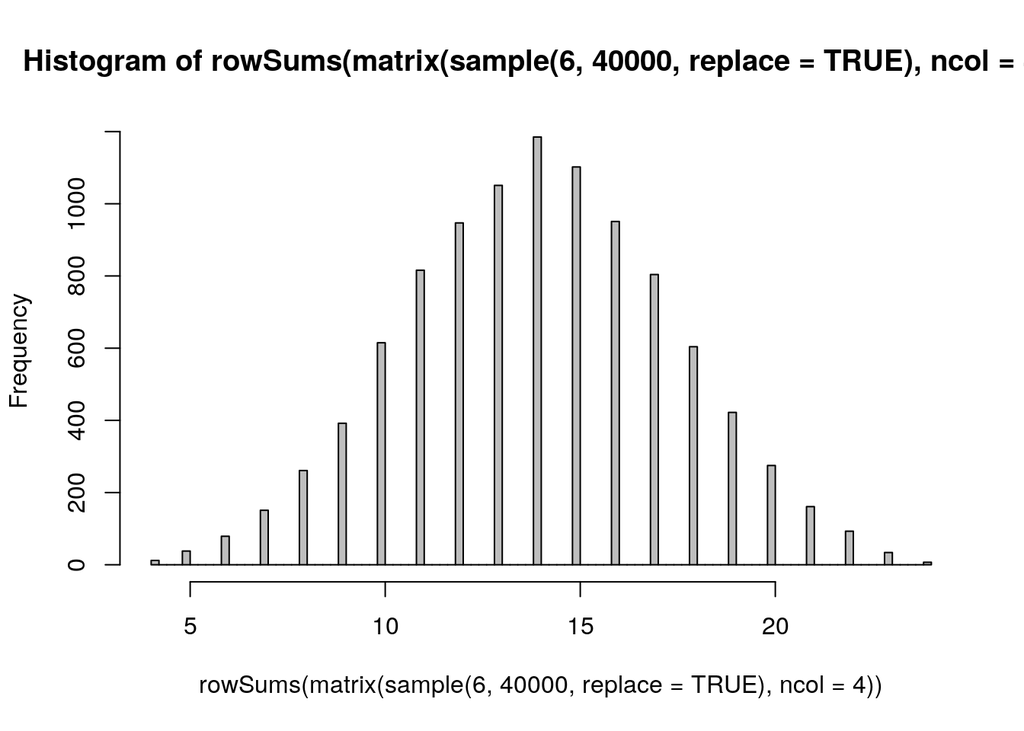

```r
hist( rowSums( matrix( sample( 6, 40000, replace=TRUE ), ncol=4 ) ), col="gray", breaks=100)
```

Schaut schon etwas glockenförmig aus.

Zehn Würfel:

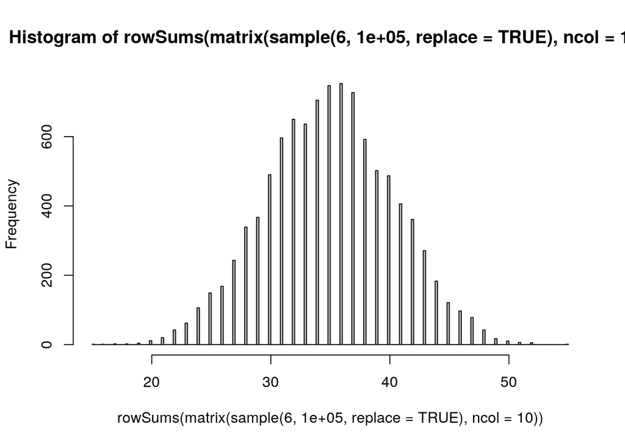

```r
hist( rowSums( matrix( sample( 6, 100000, replace=TRUE ), ncol=10 ) ), col="gray", breaks=200)
```

## t-Test, demonstriert per Simulation

Hypothese: Menschen, die bei Vollmond geboren wurden, sind als Erwachsene größer als Menschen, die bei Neumond geboren wurden.

Simulierte Daten, für die die Hypothese falsch ist

```r
# Größe von 20 Vollmond-Menschen
hA <- rnorm( 20, 178, 7 )

# Größe von 20 Neumond-Menschen
hB <- rnorm( 20, 178, 7 )
```

t-Test:

```r
t.test( hA, hB )
```

```
##
##  Welch Two Sample t-test
##
## data:  hA and hB
## t = -1.3624, df = 35.343, p-value = 0.1817
## alternative hypothesis: true difference in means is not equal to 0
## 95 percent confidence interval:
##  -8.367611  1.645409
## sample estimates:
## mean of x mean of y
##  176.3387  179.6998
```

Simuliere, dass 1000 Forscher diese Untersuchung machen

```r
pvals <- replicate( 1000, {
  hA <- rnorm( 20, 178, 7 )
  hB <- rnorm( 20, 178, 7 )
  t.test( hA, hB )$p.value
} )
```

Ihre p-Werte sind uniform verteilt:

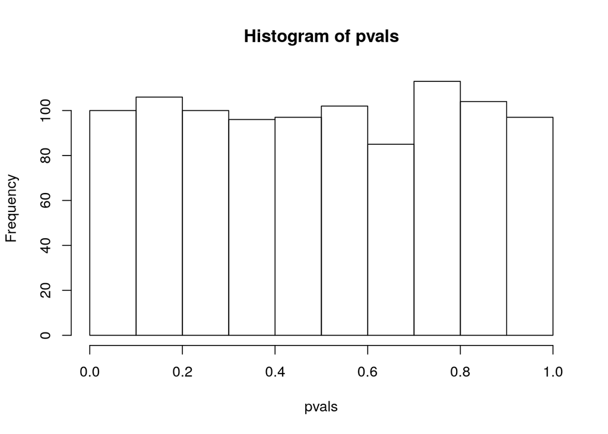

```r
hist( pvals )
```

Etwa 5% der Forscher glauben daher, ein signifikantes Ergebnis gefunden zu haben (falls sie p<=0.05 als Signifikanzgrenze verwenden).

xkcd #882 illustriert das Problem: https://xkcd.com/882/

## False discovery rate und Benjamini-Hochberg-Korrektur

Oft testen wir in einem Experiment viele Hypothesen: bei einem RNA-Seq-Experiment testen wir zB jedes Gen. Dies für zum Problem des “multiple testing”:

Beispiel: Wir testen 10,000 Gene und erhalten für jedes einen p-Wert. Wir betrachten nun alle Gene mit $p\le 0.01$ als statistisch signifikant. Selbst wenn für alle Gene die Nullhypothese gälte, würden wir erwarten, dass 1% der Gene, also 100 Gene, einen p-Wert unter 1% erhalten. Wenn wir tatsächlich 500 signifikante Gene (mit $p\le 0.01$) erhalte, so müssen wir davon ausgehen, dass diese Liste 100 Falsch-Positive enthält. Die *false discovery rate* (FDR) beträgt alse 20%. Falls uns das zu viel ist, können wir einen kleineren Grenzwert für Signifikanz wählen.

Benjamini-Hochberg-Adjustierung (BH adjustment for multiple testing): Benjamini und Hochberg, die das Konzept der FDR eingeführt haben, schlagen vor, für jeden einzelnen p-Wert mittels des eben beschriebenen Schemas zu bestimmen, wie groß die FDR wäre, wenn man diesen p-Wert als Signifikanz-Grenze wählte. Dieser FDR-Wert wird oft als der BH-adjustierte p-Wert bezeichnet. In R berechnet die Funtion `p.adjust` (mit `method="BH"`) für einen Vektor mit p-Werten die BH-adjustierten Werte. Um eine Liste mit einer gewünschten FDR zu erhalten, nimmt man all jene Gene, die einen adjustierten p-Wert unter der gewünschten FDR haben.